# 07_05_2020

## The Daily Graph

### Introduction and summary.

#### Although not as striking as Leon county, for both Hamilton and Fulton Counties number of new cases daily appear to be increasing rapidly.

#### The Campbell county data is the most difficult to interpret. The moving average number of new cases daily is increasing but no where near the level of the other counties. I suspect but have absolutely no evidence, that there is a reasonable probability that some cases for Campbell county are actually counted in Hamilton county since I think a reasonable number of people in Campbell county get their medical care in Hamilton county.

```
          07/05/2020
```

### Summary for selected counties

| Statistic | Campbell, KY | Fulton, GA | Hamilton, OH | Leon, FL |
| --- | --- | --- | --- | --- |
| Population | 93,584 | 1,063,937 | 817,473 | 293,582 |
| Cases | 270 | 8,433 | 5,770 | 1,638 |
| Deaths | 13 | 314 | 197 | 8 |
| Cases per 100,000 | 288 | 792 | 705 | 557 |
| Deaths per 100,000 | 13 | 29 | 24 | 2 |
| Date of first case | 3/24/20 | 3/3/20 | 3/19/20 | 3/19/20 |
| Number of Days | 103 | 124 | 108 | 108 |
| Maximum Number of Cases | 18 | 520 | 381 | 228 |

## The last 7 days

The following table displays the number of new cases for the lastest 7 days of available data in each of the counties. The zero probably means a missing day's data since I calculate new cases based on the cumulative number.

| Date | Campbell | Fulton | Hamilton | Leon |
| --- | --- | --- | --- | --- |
| 6/28/20 | 2 | 104 | 133 | 176 |
| 6/29/20 | 1 | 38 | 128 | 47 |
| 6/30/20 | 7 | 317 | 88 | 116 |
| 7/1/20 | 6 | 312 | 214 | 35 |
| 7/2/20 | 5 | 250 | 0 | 228 |
| 7/3/20 | 3 | 386 | 381 | 89 |
| 7/4/20 | 0 | 520 | 165 | 172 |

## Examine new cases, moving averages

The moving averages have now been normalized as the number of cases per 100,000 population. As noted before, the averages are 'trailing' in that the point on the graph represents the average number of new confirmed cases for that day and the $k-1$ previous days ($k = 5,7,10$).

### A comparison of moving averages amongst the counties.

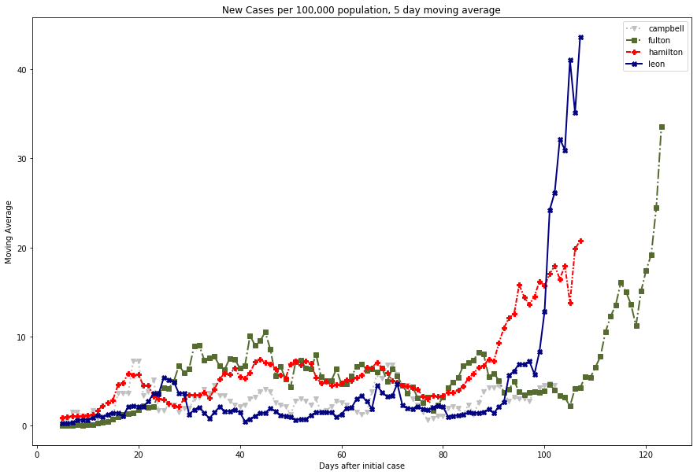

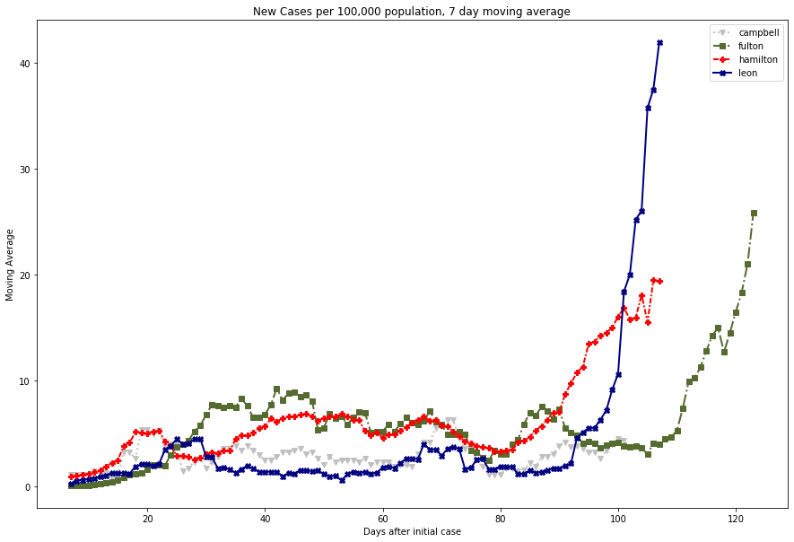

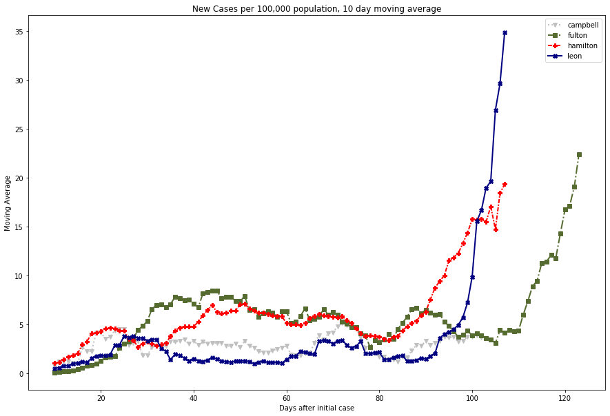

### A comparison of the different moving averages within counties.

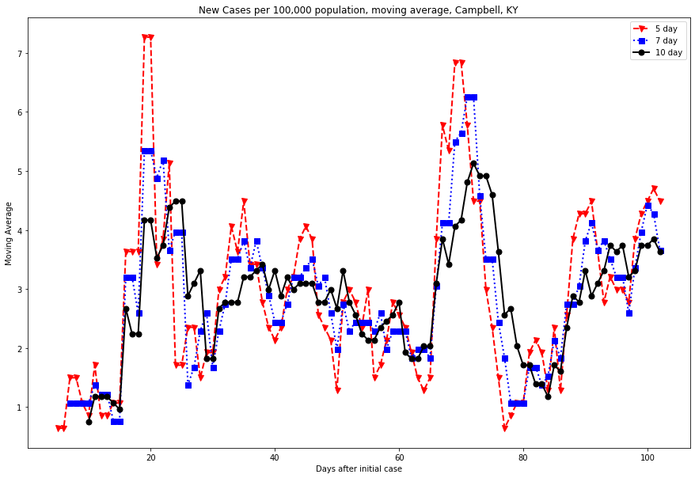

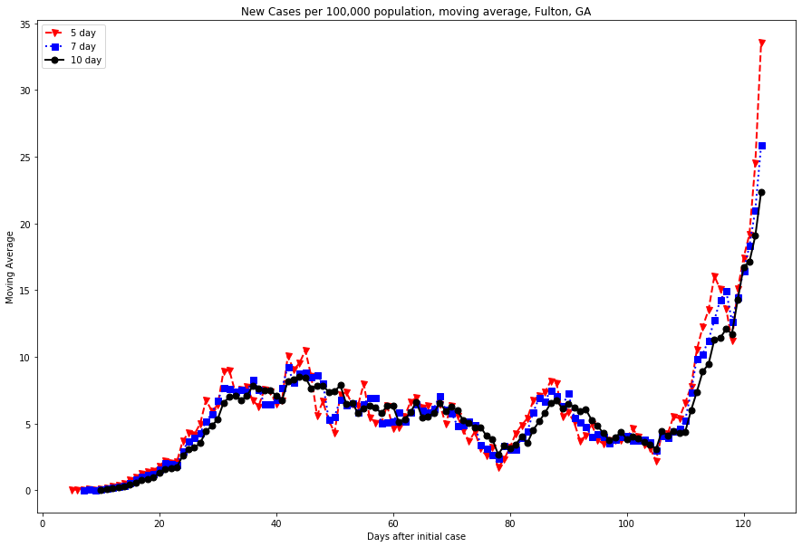

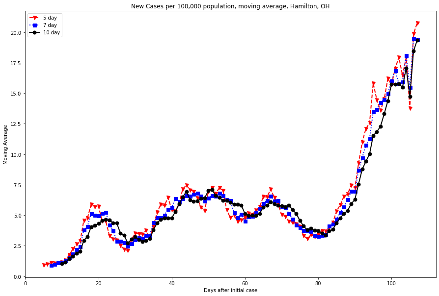

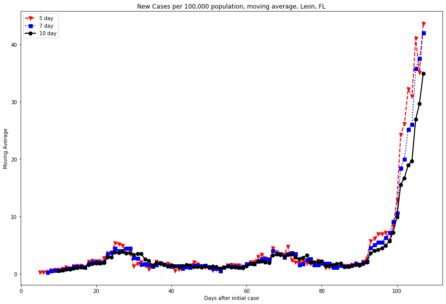

## Cumulative Number of cases by county.

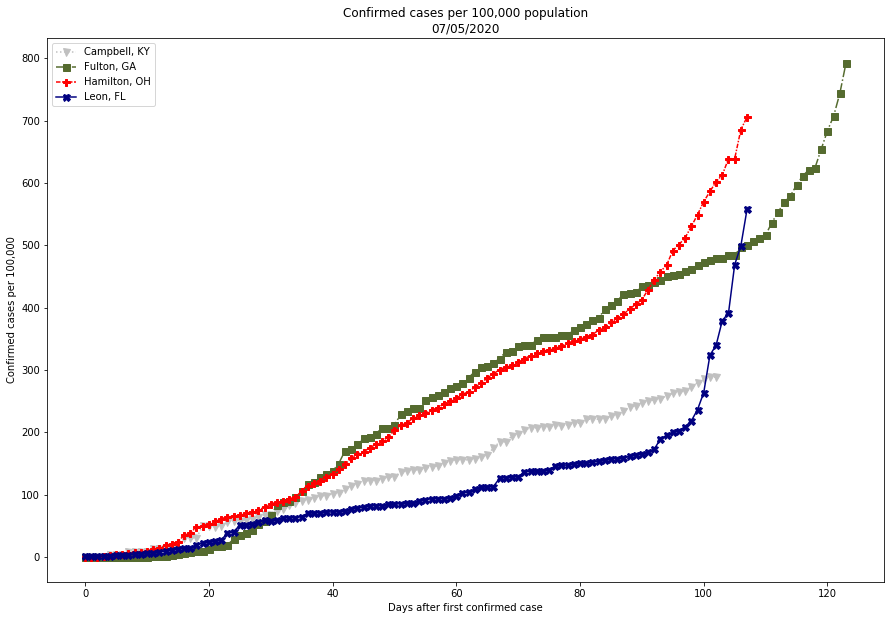

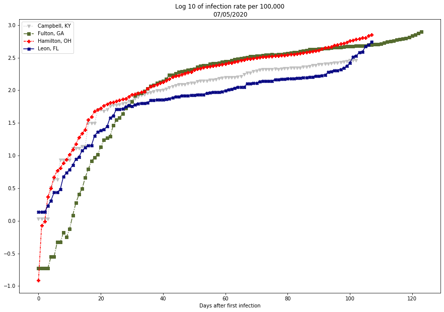